# Risk Factor Analysis

## Outcome Variable

**Outcome Variable:** y_rate_haz

## Predictor Variables

**Intervention Variable:** mbmi

**Adjustment Set:**

unadjusted

## Stratifying Variables

The analysis was stratified on these variable(s):

- diffcat
- studyid
- country

## Data Summary

| diffcat | studyid | country | mbmi | n_cell | n |
| --- | --- | --- | --- | --- | --- |
| 0-3 months | ki0047075b-MAL-ED | BANGLADESH | [18.5-25) | 157 | 244 |
| 0-3 months | ki0047075b-MAL-ED | BANGLADESH | <18.5 | 32 | 244 |
| 0-3 months | ki0047075b-MAL-ED | BANGLADESH | [25-30) | 49 | 244 |
| 0-3 months | ki0047075b-MAL-ED | BANGLADESH | >=30 | 6 | 244 |
| 3-6 months | ki0047075b-MAL-ED | BANGLADESH | [18.5-25) | 147 | 231 |
| 3-6 months | ki0047075b-MAL-ED | BANGLADESH | <18.5 | 30 | 231 |
| 3-6 months | ki0047075b-MAL-ED | BANGLADESH | [25-30) | 48 | 231 |
| 3-6 months | ki0047075b-MAL-ED | BANGLADESH | >=30 | 6 | 231 |
| 6-12 months | ki0047075b-MAL-ED | BANGLADESH | [18.5-25) | 142 | 220 |
| 6-12 months | ki0047075b-MAL-ED | BANGLADESH | <18.5 | 26 | 220 |
| 6-12 months | ki0047075b-MAL-ED | BANGLADESH | [25-30) | 47 | 220 |
| 6-12 months | ki0047075b-MAL-ED | BANGLADESH | >=30 | 5 | 220 |
| 12-24 months | ki0047075b-MAL-ED | BANGLADESH | [18.5-25) | 131 | 206 |
| 12-24 months | ki0047075b-MAL-ED | BANGLADESH | <18.5 | 27 | 206 |
| 12-24 months | ki0047075b-MAL-ED | BANGLADESH | [25-30) | 44 | 206 |
| 12-24 months | ki0047075b-MAL-ED | BANGLADESH | >=30 | 4 | 206 |
| 12-24 months | ki1000110-WASH-Bangladesh | BANGLADESH | [18.5-25) | 21 | 38 |
| 12-24 months | ki1000110-WASH-Bangladesh | BANGLADESH | <18.5 | 17 | 38 |
| 0-3 months | ki1017093-NIH-Birth | BANGLADESH | [18.5-25) | 400 | 566 |
| 0-3 months | ki1017093-NIH-Birth | BANGLADESH | <18.5 | 94 | 566 |
| 0-3 months | ki1017093-NIH-Birth | BANGLADESH | [25-30) | 58 | 566 |
| 0-3 months | ki1017093-NIH-Birth | BANGLADESH | >=30 | 14 | 566 |
| 3-6 months | ki1017093-NIH-Birth | BANGLADESH | [18.5-25) | 363 | 523 |
| 3-6 months | ki1017093-NIH-Birth | BANGLADESH | <18.5 | 91 | 523 |
| 3-6 months | ki1017093-NIH-Birth | BANGLADESH | [25-30) | 55 | 523 |
| 3-6 months | ki1017093-NIH-Birth | BANGLADESH | >=30 | 14 | 523 |
| 6-12 months | ki1017093-NIH-Birth | BANGLADESH | [18.5-25) | 331 | 482 |
| 6-12 months | ki1017093-NIH-Birth | BANGLADESH | <18.5 | 89 | 482 |
| 6-12 months | ki1017093-NIH-Birth | BANGLADESH | [25-30) | 53 | 482 |
| 6-12 months | ki1017093-NIH-Birth | BANGLADESH | >=30 | 9 | 482 |

[output cut: 201 more lines]

The following strata were considered:

- diffcat: 0-3 months, studyid: ki0047075b-MAL-ED, country: BANGLADESH
- diffcat: 0-3 months, studyid: ki0047075b-MAL-ED, country: BRAZIL
- diffcat: 0-3 months, studyid: ki0047075b-MAL-ED, country: INDIA
- diffcat: 0-3 months, studyid: ki0047075b-MAL-ED, country: NEPAL
- diffcat: 0-3 months, studyid: ki0047075b-MAL-ED, country: PERU
- diffcat: 0-3 months, studyid: ki0047075b-MAL-ED, country: SOUTH AFRICA
- diffcat: 0-3 months, studyid: ki0047075b-MAL-ED, country: TANZANIA, UNITED REPUBLIC OF
- diffcat: 0-3 months, studyid: ki1000304b-SAS-CompFeed, country: INDIA
- diffcat: 0-3 months, studyid: ki1017093-NIH-Birth, country: BANGLADESH
- diffcat: 0-3 months, studyid: ki1017093b-PROVIDE, country: BANGLADESH
- diffcat: 0-3 months, studyid: ki1017093c-NIH-Crypto, country: BANGLADESH
- diffcat: 0-3 months, studyid: ki1119695-PROBIT, country: BELARUS
- diffcat: 0-3 months, studyid: ki1126311-ZVITAMBO, country: ZIMBABWE
- diffcat: 12-24 months, studyid: ki0047075b-MAL-ED, country: BANGLADESH
- diffcat: 12-24 months, studyid: ki0047075b-MAL-ED, country: BRAZIL
- diffcat: 12-24 months, studyid: ki0047075b-MAL-ED, country: INDIA
- diffcat: 12-24 months, studyid: ki0047075b-MAL-ED, country: NEPAL
- diffcat: 12-24 months, studyid: ki0047075b-MAL-ED, country: PERU
- diffcat: 12-24 months, studyid: ki0047075b-MAL-ED, country: SOUTH AFRICA
- diffcat: 12-24 months, studyid: ki0047075b-MAL-ED, country: TANZANIA, UNITED REPUBLIC OF
- diffcat: 12-24 months, studyid: ki1000110-WASH-Bangladesh, country: BANGLADESH
- diffcat: 12-24 months, studyid: ki1017093-NIH-Birth, country: BANGLADESH
- diffcat: 12-24 months, studyid: ki1017093b-PROVIDE, country: BANGLADESH
- diffcat: 12-24 months, studyid: ki1017093c-NIH-Crypto, country: BANGLADESH
- diffcat: 12-24 months, studyid: ki1066203-TanzaniaChild2, country: TANZANIA, UNITED REPUBLIC OF
- diffcat: 12-24 months, studyid: ki1112895-Burkina Faso Zn, country: BURKINA FASO
- diffcat: 12-24 months, studyid: ki1119695-PROBIT, country: BELARUS
- diffcat: 12-24 months, studyid: ki1126311-ZVITAMBO, country: ZIMBABWE
- diffcat: 12-24 months, studyid: ki1148112-iLiNS-DOSE, country: MALAWI
- diffcat: 12-24 months, studyid: ki1148112-LCNI-5, country: MALAWI
- diffcat: 3-6 months, studyid: ki0047075b-MAL-ED, country: BANGLADESH
- diffcat: 3-6 months, studyid: ki0047075b-MAL-ED, country: BRAZIL
- diffcat: 3-6 months, studyid: ki0047075b-MAL-ED, country: INDIA
- diffcat: 3-6 months, studyid: ki0047075b-MAL-ED, country: NEPAL
- diffcat: 3-6 months, studyid: ki0047075b-MAL-ED, country: PERU
- diffcat: 3-6 months, studyid: ki0047075b-MAL-ED, country: SOUTH AFRICA
- diffcat: 3-6 months, studyid: ki0047075b-MAL-ED, country: TANZANIA, UNITED REPUBLIC OF
- diffcat: 3-6 months, studyid: ki1000304b-SAS-CompFeed, country: INDIA
- diffcat: 3-6 months, studyid: ki1017093-NIH-Birth, country: BANGLADESH
- diffcat: 3-6 months, studyid: ki1017093b-PROVIDE, country: BANGLADESH
- diffcat: 3-6 months, studyid: ki1017093c-NIH-Crypto, country: BANGLADESH
- diffcat: 3-6 months, studyid: ki1066203-TanzaniaChild2, country: TANZANIA, UNITED REPUBLIC OF
- diffcat: 3-6 months, studyid: ki1119695-PROBIT, country: BELARUS
- diffcat: 3-6 months, studyid: ki1126311-ZVITAMBO, country: ZIMBABWE
- diffcat: 6-12 months, studyid: ki0047075b-MAL-ED, country: BANGLADESH
- diffcat: 6-12 months, studyid: ki0047075b-MAL-ED, country: BRAZIL
- diffcat: 6-12 months, studyid: ki0047075b-MAL-ED, country: INDIA
- diffcat: 6-12 months, studyid: ki0047075b-MAL-ED, country: NEPAL
- diffcat: 6-12 months, studyid: ki0047075b-MAL-ED, country: PERU
- diffcat: 6-12 months, studyid: ki0047075b-MAL-ED, country: SOUTH AFRICA
- diffcat: 6-12 months, studyid: ki0047075b-MAL-ED, country: TANZANIA, UNITED REPUBLIC OF
- diffcat: 6-12 months, studyid: ki1000304b-SAS-CompFeed, country: INDIA
- diffcat: 6-12 months, studyid: ki1017093-NIH-Birth, country: BANGLADESH
- diffcat: 6-12 months, studyid: ki1017093b-PROVIDE, country: BANGLADESH
- diffcat: 6-12 months, studyid: ki1017093c-NIH-Crypto, country: BANGLADESH
- diffcat: 6-12 months, studyid: ki1066203-TanzaniaChild2, country: TANZANIA, UNITED REPUBLIC OF
- diffcat: 6-12 months, studyid: ki1119695-PROBIT, country: BELARUS
- diffcat: 6-12 months, studyid: ki1126311-ZVITAMBO, country: ZIMBABWE
- diffcat: 6-12 months, studyid: ki1148112-iLiNS-DOSE, country: MALAWI
- diffcat: 6-12 months, studyid: ki1148112-iLiNS-DYAD-M, country: MALAWI
- diffcat: 6-12 months, studyid: ki1148112-LCNI-5, country: MALAWI

### Dropped Strata

Some strata were dropped due to rare outcomes:

- diffcat: 12-24 months, studyid: ki0047075b-MAL-ED, country: BANGLADESH
- diffcat: 12-24 months, studyid: ki1112895-Burkina Faso Zn, country: BURKINA FASO
- diffcat: 0-3 months, studyid: ki1000304b-SAS-CompFeed, country: INDIA
- diffcat: 6-12 months, studyid: ki1148112-LCNI-5, country: MALAWI
- diffcat: 12-24 months, studyid: ki1148112-LCNI-5, country: MALAWI
- diffcat: 6-12 months, studyid: ki1148112-iLiNS-DYAD-M, country: MALAWI
- diffcat: 6-12 months, studyid: ki0047075b-MAL-ED, country: PERU
- diffcat: 12-24 months, studyid: ki0047075b-MAL-ED, country: PERU
- diffcat: 0-3 months, studyid: ki0047075b-MAL-ED, country: SOUTH AFRICA
- diffcat: 12-24 months, studyid: ki1066203-TanzaniaChild2, country: TANZANIA, UNITED REPUBLIC OF

## Methods Detail

We’re interested in the causal parameters $E[Y_a]$ for all values of $a \in \mathcal{A}$. These parameters represent the mean outcome if, possibly contrary to fact, we intervened to set all units to have $A=a$. Under the randomization and positivity assumptions, these are identified by the statistical parameters $\psi_a=E_W[E_{Y|A,W}(Y|A=a,W)]$. In addition, we’re interested in the mean of $Y$, $E[Y]$ under no intervention (the observed mean). We will estimate these parameters by using SuperLearner to fit the relevant likelihood factors – $E_{Y|A,W}(Y|A=a,W)$ and $p(A=a|W)$, and then updating our likelihood fit using a joint TMLE.

For unadjusted analyses ($W=\{\}$), initial likelihoods were estimated using Lrnr_glm to estimate the simple $E(Y|A)$ and Lrnr_mean to estimate $p(A)$. For adjusted analyses, a small library containing Lrnr_glmnet, Lrnr_xgboost, and Lrnr_mean was used.

Having estimated these parameters, we will then use the delta method to estimate relative risks and attributable risks relative to a prespecified baseline level of $A$.

# Results Detail

## Results Plots

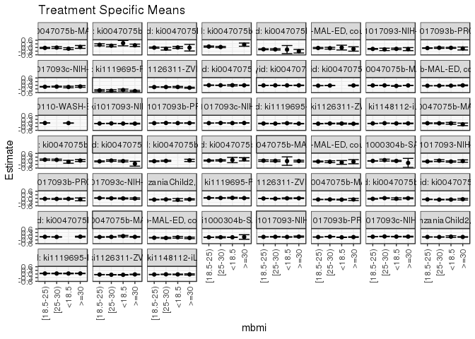

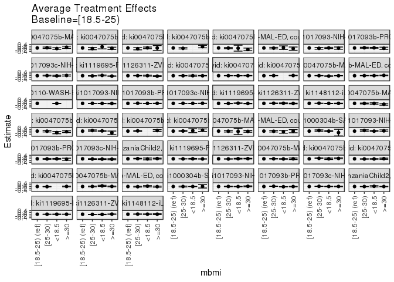

## Results Table

### Parameter: TSM

| diffcat | studyid | country | intervention_level | baseline_level | estimate | ci_lower | ci_upper |
| --- | --- | --- | --- | --- | --- | --- | --- |
| 0-3 months | ki0047075b-MAL-ED | BANGLADESH | [18.5-25) | NA | -0.0327745 | -0.0734690 | 0.0079200 |
| 0-3 months | ki0047075b-MAL-ED | BANGLADESH | <18.5 | NA | -0.0973296 | -0.1774763 | -0.0171828 |
| 0-3 months | ki0047075b-MAL-ED | BANGLADESH | [25-30) | NA | -0.0057477 | -0.0780670 | 0.0665716 |
| 0-3 months | ki0047075b-MAL-ED | BANGLADESH | >=30 | NA | 0.0447760 | -0.0729637 | 0.1625156 |
| 0-3 months | ki0047075b-MAL-ED | BRAZIL | [18.5-25) | NA | 0.2201664 | 0.1343810 | 0.3059519 |
| 0-3 months | ki0047075b-MAL-ED | BRAZIL | <18.5 | NA | 0.3585008 | 0.1357292 | 0.5812724 |
| 0-3 months | ki0047075b-MAL-ED | BRAZIL | [25-30) | NA | 0.1487288 | 0.0592124 | 0.2382451 |
| 0-3 months | ki0047075b-MAL-ED | BRAZIL | >=30 | NA | 0.1819975 | 0.0866926 | 0.2773024 |
| 0-3 months | ki0047075b-MAL-ED | INDIA | [18.5-25) | NA | -0.0094898 | -0.0557653 | 0.0367857 |
| 0-3 months | ki0047075b-MAL-ED | INDIA | <18.5 | NA | 0.0059316 | -0.0733688 | 0.0852321 |
| 0-3 months | ki0047075b-MAL-ED | INDIA | [25-30) | NA | -0.0957663 | -0.2099983 | 0.0184657 |
| 0-3 months | ki0047075b-MAL-ED | INDIA | >=30 | NA | -0.0144465 | -0.2872053 | 0.2583123 |
| 0-3 months | ki0047075b-MAL-ED | NEPAL | [18.5-25) | NA | 0.0789351 | 0.0310660 | 0.1268042 |
| 0-3 months | ki0047075b-MAL-ED | NEPAL | [25-30) | NA | 0.0391113 | -0.0127382 | 0.0909608 |
| 0-3 months | ki0047075b-MAL-ED | NEPAL | >=30 | NA | 0.2347508 | 0.1016876 | 0.3678140 |
| 0-3 months | ki0047075b-MAL-ED | PERU | [18.5-25) | NA | -0.1432917 | -0.1837315 | -0.1028519 |
| 0-3 months | ki0047075b-MAL-ED | PERU | <18.5 | NA | -0.1683951 | -0.4989930 | 0.1622028 |
| 0-3 months | ki0047075b-MAL-ED | PERU | [25-30) | NA | -0.1535944 | -0.2092293 | -0.0979595 |
| 0-3 months | ki0047075b-MAL-ED | PERU | >=30 | NA | -0.3044496 | -0.4519605 | -0.1569386 |
| 0-3 months | ki0047075b-MAL-ED | TANZANIA, UNITED REPUBLIC OF | [18.5-25) | NA | -0.0414233 | -0.0882767 | 0.0054301 |
| 0-3 months | ki0047075b-MAL-ED | TANZANIA, UNITED REPUBLIC OF | <18.5 | NA | -0.0080470 | -0.2038247 | 0.1877307 |
| 0-3 months | ki0047075b-MAL-ED | TANZANIA, UNITED REPUBLIC OF | [25-30) | NA | -0.0576882 | -0.1340225 | 0.0186462 |
| 0-3 months | ki0047075b-MAL-ED | TANZANIA, UNITED REPUBLIC OF | >=30 | NA | -0.1198722 | -0.3010483 | 0.0613039 |
| 0-3 months | ki1017093-NIH-Birth | BANGLADESH | [18.5-25) | NA | -0.1152883 | -0.1475827 | -0.0829940 |
| 0-3 months | ki1017093-NIH-Birth | BANGLADESH | <18.5 | NA | -0.1122864 | -0.1716046 | -0.0529682 |
| 0-3 months | ki1017093-NIH-Birth | BANGLADESH | [25-30) | NA | -0.1535042 | -0.2501506 | -0.0568577 |
| 0-3 months | ki1017093-NIH-Birth | BANGLADESH | >=30 | NA | -0.1318888 | -0.2556606 | -0.0081170 |
| 0-3 months | ki1017093b-PROVIDE | BANGLADESH | [18.5-25) | NA | -0.0475424 | -0.0699729 | -0.0251119 |
| 0-3 months | ki1017093b-PROVIDE | BANGLADESH | <18.5 | NA | -0.0271459 | -0.0680712 | 0.0137794 |
| 0-3 months | ki1017093b-PROVIDE | BANGLADESH | [25-30) | NA | -0.0215326 | -0.0710244 | 0.0279591 |

[output cut: 168 more lines]

### Parameter: E(Y)

| diffcat | studyid | country | intervention_level | baseline_level | estimate | ci_lower | ci_upper |
| --- | --- | --- | --- | --- | --- | --- | --- |
| 0-3 months | ki0047075b-MAL-ED | BANGLADESH | NA | NA | -0.0339062 | -0.0659795 | -0.0018330 |
| 0-3 months | ki0047075b-MAL-ED | BRAZIL | NA | NA | 0.1928587 | 0.1409027 | 0.2448147 |
| 0-3 months | ki0047075b-MAL-ED | INDIA | NA | NA | -0.0204797 | -0.0596747 | 0.0187152 |
| 0-3 months | ki0047075b-MAL-ED | NEPAL | NA | NA | 0.0746202 | 0.0395269 | 0.1097135 |
| 0-3 months | ki0047075b-MAL-ED | PERU | NA | NA | -0.1572370 | -0.1898325 | -0.1246414 |
| 0-3 months | ki0047075b-MAL-ED | TANZANIA, UNITED REPUBLIC OF | NA | NA | -0.0461667 | -0.0847570 | -0.0075763 |
| 0-3 months | ki1017093-NIH-Birth | BANGLADESH | NA | NA | -0.1191165 | -0.1460676 | -0.0921654 |
| 0-3 months | ki1017093b-PROVIDE | BANGLADESH | NA | NA | -0.0408226 | -0.0589776 | -0.0226676 |
| 0-3 months | ki1017093c-NIH-Crypto | BANGLADESH | NA | NA | -0.1220821 | -0.1402761 | -0.1038881 |
| 0-3 months | ki1119695-PROBIT | BELARUS | NA | NA | -0.4366058 | -0.4962029 | -0.3770087 |
| 0-3 months | ki1126311-ZVITAMBO | ZIMBABWE | NA | NA | -0.1519662 | -0.1630450 | -0.1408873 |
| 3-6 months | ki0047075b-MAL-ED | BANGLADESH | NA | NA | -0.0225211 | -0.0456381 | 0.0005960 |
| 3-6 months | ki0047075b-MAL-ED | BRAZIL | NA | NA | 0.0597008 | 0.0230362 | 0.0963653 |
| 3-6 months | ki0047075b-MAL-ED | INDIA | NA | NA | -0.0417054 | -0.0700621 | -0.0133486 |
| 3-6 months | ki0047075b-MAL-ED | NEPAL | NA | NA | -0.0214542 | -0.0480456 | 0.0051373 |
| 3-6 months | ki0047075b-MAL-ED | PERU | NA | NA | 0.0272742 | -0.0038596 | 0.0584080 |
| 3-6 months | ki0047075b-MAL-ED | SOUTH AFRICA | NA | NA | -0.0042614 | -0.0425659 | 0.0340432 |
| 3-6 months | ki0047075b-MAL-ED | TANZANIA, UNITED REPUBLIC OF | NA | NA | -0.0705448 | -0.1027245 | -0.0383652 |
| 3-6 months | ki1000304b-SAS-CompFeed | INDIA | NA | NA | -0.0097258 | -0.0280274 | 0.0085758 |
| 3-6 months | ki1017093-NIH-Birth | BANGLADESH | NA | NA | -0.0509007 | -0.0730097 | -0.0287917 |
| 3-6 months | ki1017093b-PROVIDE | BANGLADESH | NA | NA | -0.0274690 | -0.0439444 | -0.0109937 |
| 3-6 months | ki1017093c-NIH-Crypto | BANGLADESH | NA | NA | 0.0267740 | 0.0099602 | 0.0435879 |
| 3-6 months | ki1066203-TanzaniaChild2 | TANZANIA, UNITED REPUBLIC OF | NA | NA | -0.0834282 | -0.1002569 | -0.0665996 |
| 3-6 months | ki1119695-PROBIT | BELARUS | NA | NA | 0.0464482 | 0.0273518 | 0.0655445 |
| 3-6 months | ki1126311-ZVITAMBO | ZIMBABWE | NA | NA | 0.0016781 | -0.0080142 | 0.0113704 |
| 6-12 months | ki0047075b-MAL-ED | BANGLADESH | NA | NA | -0.0807393 | -0.0911050 | -0.0703737 |
| 6-12 months | ki0047075b-MAL-ED | BRAZIL | NA | NA | 0.0049191 | -0.0143947 | 0.0242329 |
| 6-12 months | ki0047075b-MAL-ED | INDIA | NA | NA | -0.0785153 | -0.0906466 | -0.0663840 |
| 6-12 months | ki0047075b-MAL-ED | NEPAL | NA | NA | -0.0488126 | -0.0594641 | -0.0381610 |
| 6-12 months | ki0047075b-MAL-ED | SOUTH AFRICA | NA | NA | -0.0546626 | -0.0720558 | -0.0372694 |
| 6-12 months | ki0047075b-MAL-ED | TANZANIA, UNITED REPUBLIC OF | NA | NA | -0.1240143 | -0.1396706 | -0.1083579 |
| 6-12 months | ki1000304b-SAS-CompFeed | INDIA | NA | NA | -0.0849448 | -0.0896851 | -0.0802045 |
| 6-12 months | ki1017093-NIH-Birth | BANGLADESH | NA | NA | -0.0530976 | -0.0624028 | -0.0437924 |
| 6-12 months | ki1017093b-PROVIDE | BANGLADESH | NA | NA | -0.0626151 | -0.0695574 | -0.0556729 |
| 6-12 months | ki1017093c-NIH-Crypto | BANGLADESH | NA | NA | -0.0315658 | -0.0388594 | -0.0242722 |
| 6-12 months | ki1066203-TanzaniaChild2 | TANZANIA, UNITED REPUBLIC OF | NA | NA | -0.0594137 | -0.0686815 | -0.0501459 |
| 6-12 months | ki1119695-PROBIT | BELARUS | NA | NA | 0.0428870 | 0.0262524 | 0.0595217 |
| 6-12 months | ki1126311-ZVITAMBO | ZIMBABWE | NA | NA | -0.0493390 | -0.0542083 | -0.0444698 |
| 6-12 months | ki1148112-iLiNS-DOSE | MALAWI | NA | NA | -0.0373421 | -0.0443772 | -0.0303069 |
| 12-24 months | ki0047075b-MAL-ED | BRAZIL | NA | NA | -0.0005342 | -0.0110966 | 0.0100282 |
| 12-24 months | ki0047075b-MAL-ED | INDIA | NA | NA | -0.0098524 | -0.0150104 | -0.0046944 |
| 12-24 months | ki0047075b-MAL-ED | NEPAL | NA | NA | -0.0295113 | -0.0345712 | -0.0244514 |
| 12-24 months | ki0047075b-MAL-ED | SOUTH AFRICA | NA | NA | -0.0139716 | -0.0215484 | -0.0063947 |
| 12-24 months | ki0047075b-MAL-ED | TANZANIA, UNITED REPUBLIC OF | NA | NA | -0.0393265 | -0.0471437 | -0.0315094 |
| 12-24 months | ki1000110-WASH-Bangladesh | BANGLADESH | NA | NA | -0.0026893 | -0.0170438 | 0.0116652 |
| 12-24 months | ki1017093-NIH-Birth | BANGLADESH | NA | NA | -0.0404278 | -0.0450901 | -0.0357656 |
| 12-24 months | ki1017093b-PROVIDE | BANGLADESH | NA | NA | -0.0081718 | -0.0120131 | -0.0043304 |
| 12-24 months | ki1017093c-NIH-Crypto | BANGLADESH | NA | NA | -0.0057326 | -0.0097260 | -0.0017391 |
| 12-24 months | ki1119695-PROBIT | BELARUS | NA | NA | -0.0433028 | -0.0606990 | -0.0259066 |
| 12-24 months | ki1126311-ZVITAMBO | ZIMBABWE | NA | NA | -0.0531778 | -0.0628925 | -0.0434630 |
| 12-24 months | ki1148112-iLiNS-DOSE | MALAWI | NA | NA | -0.0307584 | -0.0356498 | -0.0258669 |

### Parameter: ATE

| diffcat | studyid | country | intervention_level | baseline_level | estimate | ci_lower | ci_upper |
| --- | --- | --- | --- | --- | --- | --- | --- |
| 0-3 months | ki0047075b-MAL-ED | BANGLADESH | [18.5-25) | [18.5-25) | 0.0000000 | 0.0000000 | 0.0000000 |
| 0-3 months | ki0047075b-MAL-ED | BANGLADESH | <18.5 | [18.5-25) | -0.0645551 | -0.1544414 | 0.0253312 |
| 0-3 months | ki0047075b-MAL-ED | BANGLADESH | [25-30) | [18.5-25) | 0.0270268 | -0.0559559 | 0.1100095 |
| 0-3 months | ki0047075b-MAL-ED | BANGLADESH | >=30 | [18.5-25) | 0.0775505 | -0.0470234 | 0.2021244 |
| 0-3 months | ki0047075b-MAL-ED | BRAZIL | [18.5-25) | [18.5-25) | 0.0000000 | 0.0000000 | 0.0000000 |
| 0-3 months | ki0047075b-MAL-ED | BRAZIL | <18.5 | [18.5-25) | 0.1383344 | -0.1003837 | 0.3770525 |
| 0-3 months | ki0047075b-MAL-ED | BRAZIL | [25-30) | [18.5-25) | -0.0714377 | -0.1954228 | 0.0525475 |
| 0-3 months | ki0047075b-MAL-ED | BRAZIL | >=30 | [18.5-25) | -0.0381689 | -0.1663960 | 0.0900581 |
| 0-3 months | ki0047075b-MAL-ED | INDIA | [18.5-25) | [18.5-25) | 0.0000000 | 0.0000000 | 0.0000000 |
| 0-3 months | ki0047075b-MAL-ED | INDIA | <18.5 | [18.5-25) | 0.0154214 | -0.0763935 | 0.1072364 |
| 0-3 months | ki0047075b-MAL-ED | INDIA | [25-30) | [18.5-25) | -0.0862765 | -0.2095257 | 0.0369727 |
| 0-3 months | ki0047075b-MAL-ED | INDIA | >=30 | [18.5-25) | -0.0049567 | -0.2816131 | 0.2716997 |
| 0-3 months | ki0047075b-MAL-ED | NEPAL | [18.5-25) | [18.5-25) | 0.0000000 | 0.0000000 | 0.0000000 |
| 0-3 months | ki0047075b-MAL-ED | NEPAL | [25-30) | [18.5-25) | -0.0398238 | -0.1103917 | 0.0307441 |
| 0-3 months | ki0047075b-MAL-ED | NEPAL | >=30 | [18.5-25) | 0.1558157 | 0.0144040 | 0.2972274 |
| 0-3 months | ki0047075b-MAL-ED | PERU | [18.5-25) | [18.5-25) | 0.0000000 | 0.0000000 | 0.0000000 |
| 0-3 months | ki0047075b-MAL-ED | PERU | <18.5 | [18.5-25) | -0.0251034 | -0.3581655 | 0.3079587 |
| 0-3 months | ki0047075b-MAL-ED | PERU | [25-30) | [18.5-25) | -0.0103027 | -0.0790822 | 0.0584769 |
| 0-3 months | ki0047075b-MAL-ED | PERU | >=30 | [18.5-25) | -0.1611578 | -0.3141116 | -0.0082041 |
| 0-3 months | ki0047075b-MAL-ED | TANZANIA, UNITED REPUBLIC OF | [18.5-25) | [18.5-25) | 0.0000000 | 0.0000000 | 0.0000000 |
| 0-3 months | ki0047075b-MAL-ED | TANZANIA, UNITED REPUBLIC OF | <18.5 | [18.5-25) | 0.0333763 | -0.1679298 | 0.2346824 |
| 0-3 months | ki0047075b-MAL-ED | TANZANIA, UNITED REPUBLIC OF | [25-30) | [18.5-25) | -0.0162649 | -0.1058315 | 0.0733017 |
| 0-3 months | ki0047075b-MAL-ED | TANZANIA, UNITED REPUBLIC OF | >=30 | [18.5-25) | -0.0784489 | -0.2655853 | 0.1086874 |
| 0-3 months | ki1017093-NIH-Birth | BANGLADESH | [18.5-25) | [18.5-25) | 0.0000000 | 0.0000000 | 0.0000000 |
| 0-3 months | ki1017093-NIH-Birth | BANGLADESH | <18.5 | [18.5-25) | 0.0030019 | -0.0645375 | 0.0705414 |
| 0-3 months | ki1017093-NIH-Birth | BANGLADESH | [25-30) | [18.5-25) | -0.0382158 | -0.1401151 | 0.0636834 |
| 0-3 months | ki1017093-NIH-Birth | BANGLADESH | >=30 | [18.5-25) | -0.0166005 | -0.1445160 | 0.1113151 |
| 0-3 months | ki1017093b-PROVIDE | BANGLADESH | [18.5-25) | [18.5-25) | 0.0000000 | 0.0000000 | 0.0000000 |
| 0-3 months | ki1017093b-PROVIDE | BANGLADESH | <18.5 | [18.5-25) | 0.0203965 | -0.0262726 | 0.0670657 |
| 0-3 months | ki1017093b-PROVIDE | BANGLADESH | [25-30) | [18.5-25) | 0.0260098 | -0.0283277 | 0.0803473 |

[output cut: 168 more lines]